# workers3

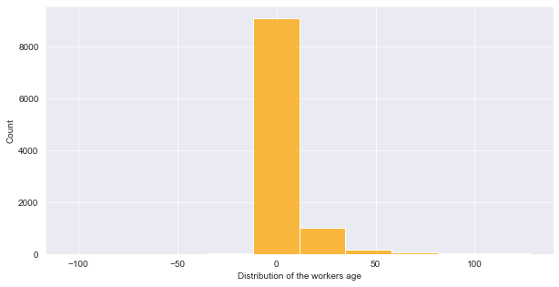

```python
#for 20% of workers
import seaborn as sns
from matplotlib import pyplot as plt
sns.set_style("darkgrid")
f, ax = plt.subplots(figsize=(10,5))
ax = sns.histplot(data=df3, x='app_to_hired_days', bins=10, color='orange')
ax.set_xlabel('Distribution of the workers age')
plt.show()
```

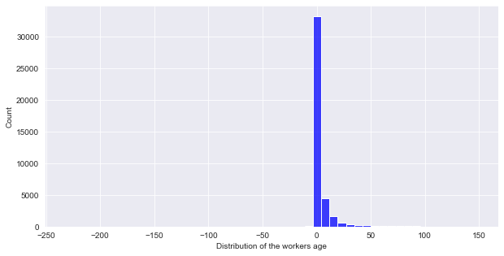

```python
#for 80% of workers
import seaborn as sns
from matplotlib import pyplot as plt
sns.set_style("darkgrid")
f, ax = plt.subplots(figsize=(10,5))
ax = sns.histplot(data=df4, x='app_to_hired_days', bins=50, color='blue')
ax.set_xlabel('Distribution of the workers age')
plt.show()
```

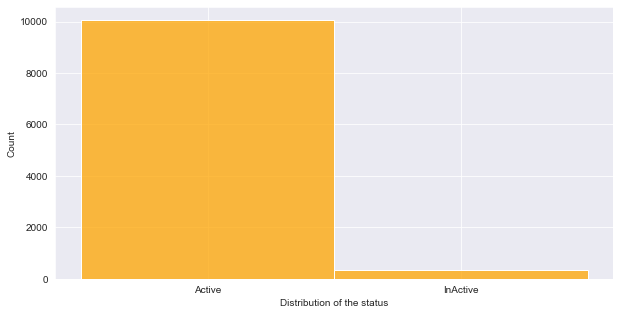

```python
#for 20% of workers
import seaborn as sns
from matplotlib import pyplot as plt
sns.set_style("darkgrid")
f, ax = plt.subplots(figsize=(10,5))
ax = sns.histplot(data=df3, x='status', bins=10, color='orange')
ax.set_xlabel('Distribution of the status')
plt.show()
```

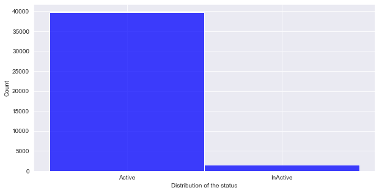

```python
#for 80% of workers
import seaborn as sns
from matplotlib import pyplot as plt
sns.set_style("darkgrid")
f, ax = plt.subplots(figsize=(10,5))
ax = sns.histplot(data=df4, x='status', bins=10, color='blue')
ax.set_xlabel('Distribution of the status')
plt.show()
```

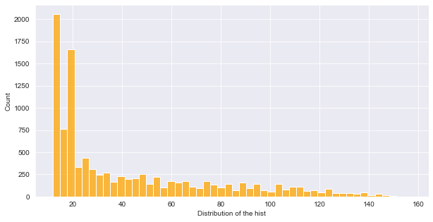

```python
#for 20% of workers
import seaborn as sns
from matplotlib import pyplot as plt
sns.set_style("darkgrid")
f, ax = plt.subplots(figsize=(10,5))
ax = sns.histplot(data=df3, x='hist', bins=50, color='orange')
ax.set_xlabel('Distribution of the hist')
plt.show()
```

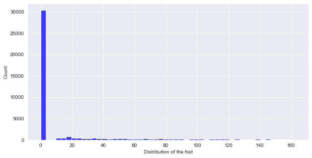

```python
#for 80% of workers
import seaborn as sns
from matplotlib import pyplot as plt
sns.set_style("darkgrid")
f, ax = plt.subplots(figsize=(10,5))
ax = sns.histplot(data=df4, x='hist', bins=50, color='blue')
ax.set_xlabel('Distribution of the hist')
plt.show()
```

### The above two graphs show that for the 20% of workers with much more total revenue, the hist value is more ditributed than the hist for the other 80%

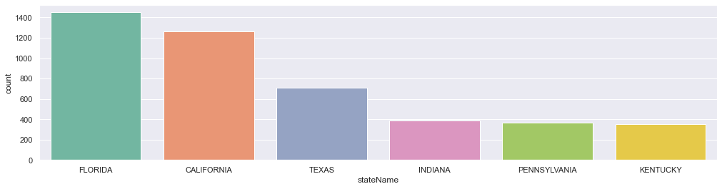

```python
#for 20% of workers
import matplotlib.pyplot as plt
import seaborn as sns
plt.figure(figsize=(17,4))
sns.set(style="darkgrid")
ax = sns.countplot(x="stateName", data=df3, palette="Set2", order=df3['stateName'].value_counts().index[0:6])
```

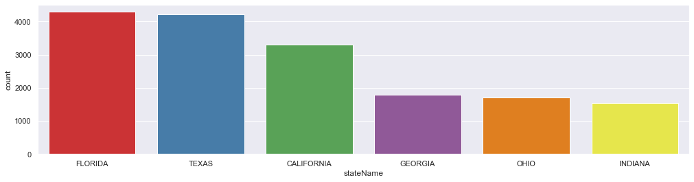

```python
#for 80% of workers
import matplotlib.pyplot as plt
import seaborn as sns
plt.figure(figsize=(17,4))
sns.set(style="darkgrid")
ax = sns.countplot(x="stateName", data=df4, palette="Set1", order=df4['stateName'].value_counts().index[0:6])
```

### The above two graphs show that for the 20% of workers with higher total value, the more states are in order "Florida,California,Texas,Indiana,Pensylvania and Kentucky" and for the other 80% it is "Florida,Texas,California,Georgia,Ohio and Indiana"

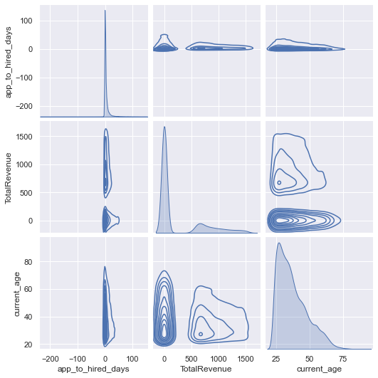

```python
cols_to_plot = ["app_to_hired_days", "TotalRevenue", "current_age"]
sns.set_theme()

sns.pairplot(df4[cols_to_plot], kind="kde")
```

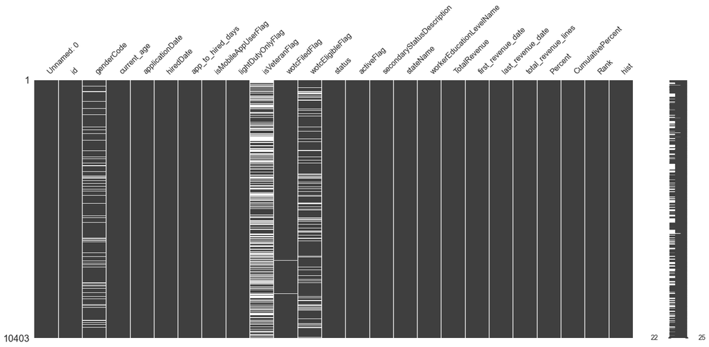

```python
import missingno as msn
msn.matrix(df3)
plt.figure(figsize = (17,9))
plt.show()
```

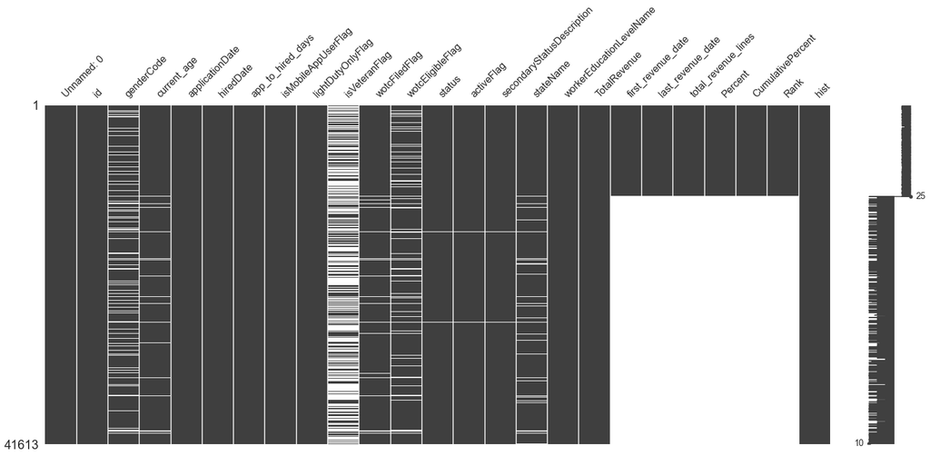

```python
import missingno as msno
msno.matrix(df4)
plt.figure(figsize = (17,9))
plt.show()
```

### The above graphs show that the missing value for the 20% of the workers with more total Revenue are less than the other 80 %

# Show Correlation heatmap

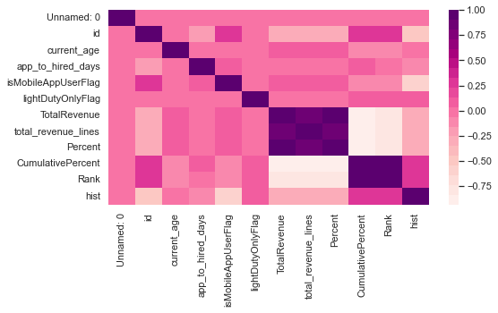

```python
#for 20% of workers
fig, ax = plt.subplots(figsize=(8,4))
sns.heatmap(df3.corr(),
            cmap= sns.color_palette("RdPu", 20),
            ax=ax)
```

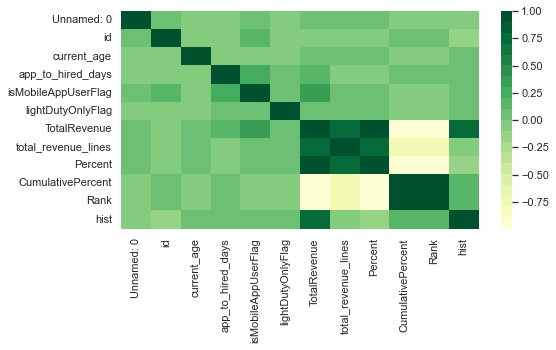

```python
#for 80% of workers
fig, ax = plt.subplots(figsize=(8,4))
sns.heatmap(df4.corr(),
            cmap= sns.color_palette("YlGn", 20),
            ax=ax)
```

```python
# Columns having missing values
missing_columns = [col for col in df3.columns if df3[col].isnull().sum() > 0]
```

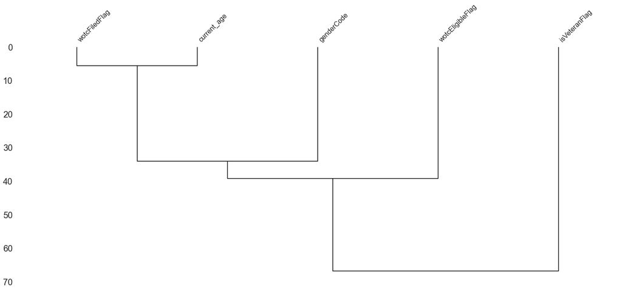

```python
#for 20% of workers
msn.dendrogram(df3[missing_columns])
```

```python
# Columns having missing values
missing_columns = [col for col in df4.columns if df4[col].isnull().sum() > 0]
```

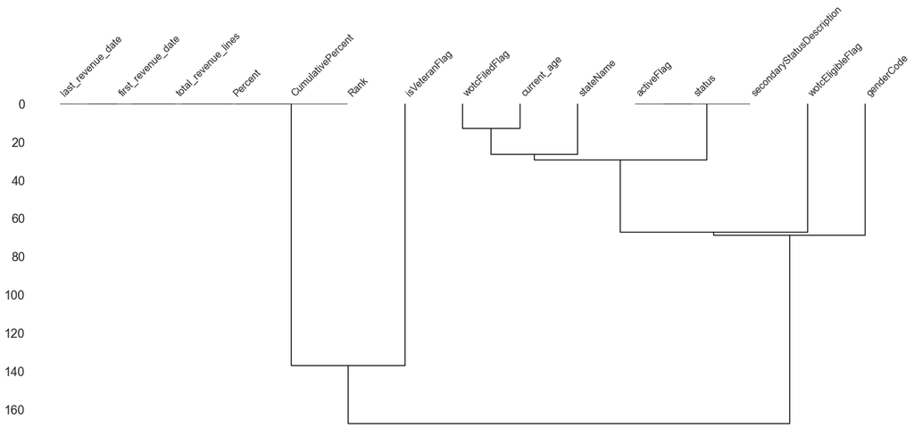

```python
#for 80% of workers
msno.dendrogram(df4[missing_columns])
```

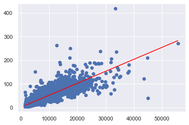

```python
x=df3.TotalRevenue
y=df3.total_revenue_lines
# plotting the data
plt.scatter(x, y)

# This will fit the best line into the graph
plt.plot(np.unique(x), np.poly1d(np.polyfit(x, y,1))
         (np.unique(x)), color='red')
```

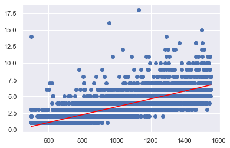

```python
data = df4.replace(np.inf, np.nan).replace(-np.inf, np.nan).dropna()
x=data.TotalRevenue
y=data.total_revenue_lines
# plotting the data
plt.scatter(x, y)

# This will fit the best line into the graph
plt.plot(np.unique(x), np.poly1d(np.polyfit(x, y,1))
         (np.unique(x)), color='red')
```

### The mean of the monetary_value for the 20% of valuable workers= 5154 that is higher than the mean of monetary_value =244 for the rest 80% of workers.

### For the 20% of workers with higher total_revenue_lines and higher TotalRevenue are more Male than Female, but it is not true about the other 80% of workers.

### 20% of workers which are more usefull use MobileApp more than the other 80 % of workers(about 3.5 times).

### With comparing the mean for ages of 2 groups we show that the 20% of workers with more total revenue, are a little older than the other 80%.

### The 20% of workers with much more total revenue have more total_revenue_lines

### Th 20% of workers with much more total revenue, are more Male and the number of Males are about 3 times more than female, but for the other 80% the number of females are not too far from the male.

### The 20% of workers with much more total revenue, the hist value is more ditributed than the hist for the other 80%.

### The 20% of workers with higher total value, the more states are in order "Florida,California,Texas,Indiana,Pensylvania and Kentucky" and for the other 80% it is "Florida,Texas,California,Georgia,Ohio and Indiana".

### The missing value for the 20% of the workers with more total Revenue are less than the other 80 %